# Name: Kaung Si Phyo

# Class : EL/EP0302/FT/04

# Title : Analysis of Town location and Flat-types where property investors should invest

## Questions

- **What are the variations in average resale prices among different towns? Are there significant disparities in property values across different locations?**
- **How have the resale prices evolved over the past 4 to 5 years? Have there been consistent upward or downward trends, or have there been fluctuations in the market?**
- **Among the unique towns, which specific flat types command higher average prices? Are there variations in pricing based on the flat type within each town?**
- **What is the distribution of remaining leases in the unique towns? Are there significant differences in lease durations, and how might this impact the long-term value and desirability of properties in each town?**
- **How strong is the correlation between median rental prices and resale prices? Does a higher median rental price generally correspond to a higher resale price, indicating potential investment opportunities with attractive rental yields?**
- **Within each town, which specific flat types demonstrate the highest median rental and resale prices? Are there consistent patterns across towns, or do certain towns exhibit unique trends in terms of rental and resale prices for different flat types?**

## Dataset links

https://data.gov.sg/dataset/resale-flat-prices  
https://data.gov.sg/dataset/median-rent-by-town-and-flat-type  
https://data.gov.sg/dataset/median-resale-prices-for-registered-applications-by-town-and-flat-type

## Dataset: resale-flat-prices-based-on-registration-date-from-jan-2017-onwards

### Nature of the dataset:

This dataset contains information about the resale prices of flats in Singapore based on their registration date from January 2017 onwards. It includes details such as the registration date, town, flat type, storey range, floor area, lease commencement date, remaining lease, resale price, and more.

### Peculiarities:

One peculiarity of this dataset is that it focuses on resale flat prices rather than new flat prices. It provides insights into the housing market in Singapore and the trends in resale flat prices over time.

### Process of analysis:

To analyze this dataset,first, I read the data and their meaning, analyse the few hundred rows, then I loaded the data using the np.genfromtxt function, specifying the delimiter, data type, and skipping the header. I then extracted relevant columns such as months, towns, and prices. I performed various operations like calculating unique towns, converting data types, and visualizing the data using matplotlib.

### Insights and conclusions:

By analyzing this dataset, we can gain insights into the trends and variations in resale flat prices across different towns and over time. We can observe whether the prices have increased, decreased, or remained stable. This information can be valuable for property owners looking to sell their flats or for individuals interested in monitoring the housing market. Based on the analysis, recommendations could be made regarding potential investment opportunities or market conditions in specific towns.

## Dataset: median-rent-by-town-and-flat-type

### Nature of the dataset:

The median-rent-by-town-and-flat-type dataset provides information about the median rental prices of flats in Singapore, categorized by town and flat type. It includes details such as the town name, flat type, and median rent for each combination.

### Peculiarities:

This dataset focuses on rental prices and provides insights into the average rental costs in different towns and for different types of flats. It helps understand the rental market and the variations in prices across different areas and flat types.

### Process of analysis:

To analyze this dataset,I read the data and their meaning, analyse the few hundred rows, then I load the data using the appropriate method, such as np.genfromtxt, and extract the relevant columns. I then perform statistical calculations, such as finding the median rent for each town and flat type combination. Additionally, I visualize the data using line graphs or other suitable visualization techniques to compare the median rents across different categories.

### Insights and conclusions:

Analyzing the median rent data can provide insights into the affordability of rental properties in different towns and for different flat types. It can help identify areas where rental prices are relatively higher or lower, enabling individuals to make informed decisions about housing options. The analysis can also highlight the demand and supply dynamics in the rental market and assist in assessing the rental yield potential for property investors.

## Dataset: median-resale-prices-for-registered-applications-by-town-and-flat-type

### Nature of the dataset:

The median-resale-prices-for-registered-applications-by-town-and-flat-type dataset contains information about the median resale prices of flats in Singapore based on registered applications. It includes details such as the town name, flat type, lease commencement date, resale price, and more.

### Peculiarities:

This dataset focuses on the median resale prices of flats and provides insights into the average prices for different types of flats in different towns. It can help understand the variations in resale prices across different areas and flat types.

### Process of analysis:

To analyze this dataset,I read the data and their meaning, analyse the few hundred rows, then I load the data using the appropriate method, such as np.genfromtxt, and extract the relevant columns. I then calculate the median resale prices for each town and flat type combination. Similar to the previous dataset, visualizations like line graphs are used to compare median resale prices across different categories.

### Insights and conclusions:

Analyzing the median resale prices can provide insights into the market value of different types of flats in different towns. It can help individuals assess the potential resale value of their property or make informed decisions about purchasing a resale flat. By comparing prices across different areas, one can identify areas where resale prices are relatively higher or lower, which can influence decision-making processes such as property investment or purchasing choices.

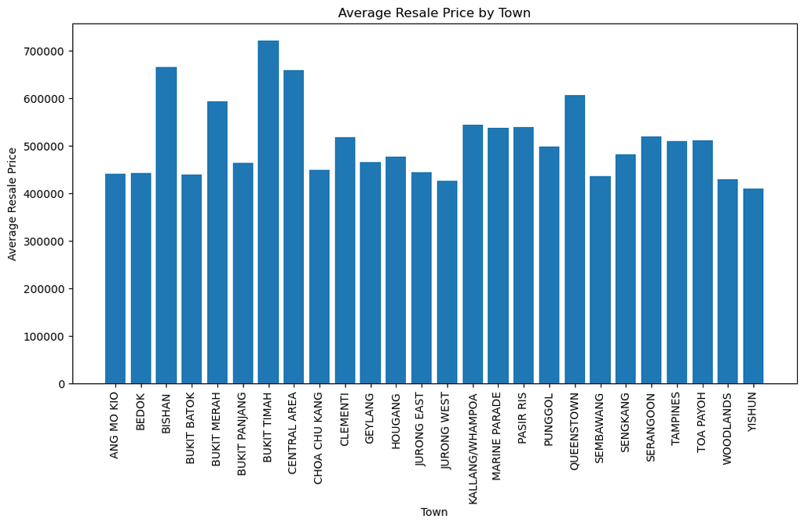

```python
import numpy as np
import matplotlib.pyplot as plt

# Load the dataset into a NumPy array
data = np.genfromtxt('./resale-flat-prices-based-on-registration-date-from-jan-2017-onwards.csv',
                     delimiter=',',
                     dtype='str',  # Set the dtype as string
                     skip_header=True)

# Extract the town and resale price columns
towns = data[:, 1]
resale_prices = data[:, -1].astype(float)

# Get unique town names and their corresponding indices
unique_towns, town_indices = np.unique(towns, return_inverse=True)

# Calculate the average resale price for each town
average_prices = np.array([np.mean(resale_prices[town_indices == i]) for i in range(len(unique_towns))])

# Plot the line graph

plt.figure(figsize=(12, 6))
plt.bar(unique_towns, average_prices)

plt.xlabel('Town')
plt.ylabel('Average Resale Price')
plt.title('Average Resale Price by Town')

plt.xticks(rotation=90)

plt.show()
```

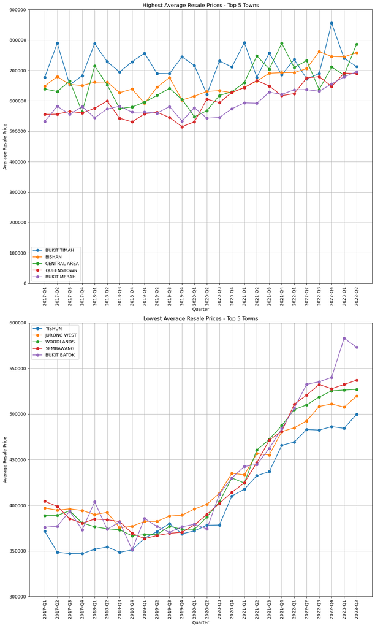

```python
import numpy as np
import matplotlib.pyplot as plt

data = np.genfromtxt('./resale-flat-prices-based-on-registration-date-from-jan-2017-onwards.csv',
                     delimiter=',',
                     dtype='str',
                     skip_header=True)

months = data[:, 0]
towns = data[:, 1]
prices = data[:, -1].astype(float)

unique_towns = np.unique(towns)
unique_months = np.unique(months)

# Reshape the months array into quarters
quarters = np.array([f"{date[:4]}-Q{((int(date[5:7]) - 1) // 3) + 1}" for date in months])


# Sort the towns based on average resale price in descending order
average_prices.sort(key=lambda x: x[1], reverse=True)

# Select the top 5 towns with highest average resale prices
selected_towns_high = [town for town, _ in average_prices[:5]]

# Sort the towns based on average resale price in ascending order
average_prices.sort(key=lambda x: x[1])
# Select the top 5 towns with lowest average resale prices
top_n_towns_low = 5
selected_towns_low = [town for town, _ in average_prices[:5]]

# Calculate the number of rows and columns for the subplot grid
n_rows = 2
n_cols = 1

# Calculate the size of the figure based on the number of subplots
fig_width = 12
fig_height = 20

# Create the figure and subplots
fig, axs = plt.subplots(n_rows, n_cols, figsize=(fig_width, fig_height))
# Plot the highest average resale prices for the selected towns
axs[0].set_title(f"Highest Average Resale Prices - Top 5 Towns")
axs[0].set_xlabel("Quarter")
axs[0].set_ylabel("Average Resale Price")
axs[0].set_ylim(0, 900000)
axs[0].grid(True)
axs[0].tick_params(axis='x', rotation=90)

for town in selected_towns_high:
    # Initialize an empty array to store the average resale prices for each quarter
    average_prices_high = []

    # Iterate over each unique quarter
    for quarter in np.unique(quarters):
        # Create a mask for the specific town and quarter
        mask = (towns == town) & (quarters == quarter)
        filtered_prices = prices[mask]

        if len(filtered_prices) > 0:
            average_price = np.mean(filtered_prices)
        else:
            average_price = 0

        average_prices_high.append(average_price)

    # Plot the average resale prices in the current subplot
    axs[0].plot(np.unique(quarters), average_prices_high, marker="o", label=town)

# Plot the lowest average resale prices for the selected towns
axs[1].set_title(f"Lowest Average Resale Prices - Top 5 Towns")
axs[1].set_xlabel("Quarter")
axs[1].set_ylabel("Average Resale Price")
axs[1].set_ylim(300000, 600000)
axs[1].grid(True)
axs[1].tick_params(axis='x', rotation=90)

for town in selected_towns_low:
    # Initialize an empty array to store the average resale prices for each quarter
    average_prices_low = []

    # Iterate over each unique quarter
    for quarter in np.unique(quarters):
        # Create a mask for the specific town and quarter
        mask = (towns == town) & (quarters == quarter)
        filtered_prices = prices[mask]

        if len(filtered_prices) > 0:
            average_price = np.mean(filtered_prices)
        else:
            average_price = 0

        average_prices_low.append(average_price)

    # Plot the average resale prices in the current subplot
    axs[1].plot(np.unique(quarters), average_prices_low, marker="o", label=town)

# Add labels to the lines
axs[0].legend()
axs[1].legend()

# Adjust the spacing between subplots
plt.tight_layout()

# Show the figure with the subplots
plt.show()
```

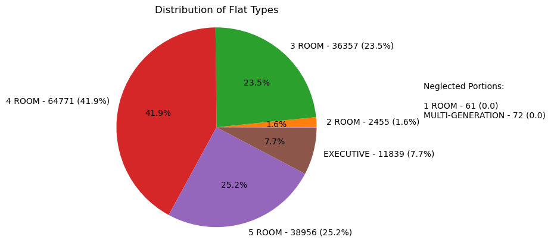

```python
import numpy as np
import matplotlib.pyplot as plt

# Load the dataset
data = np.genfromtxt('./resale-flat-prices-based-on-registration-date-from-jan-2017-onwards.csv',
                     delimiter=',',
                     dtype='str',
                     skip_header=True)

# Extract flat type column
flat_types = data[:, 2]

# Count the number of registered applications for each flat type
unique_flat_types, counts = np.unique(flat_types, return_counts=True)

# Calculate the total count
total_count = np.sum(counts)

# Calculate the percentages
percentages = (counts / total_count) * 100

# Create a list of labels by combining flat type, count, and percentage
labels = []
neglected_text = "Neglected Portions:\n" + "\n"
for flat_type, count, percentage in zip(unique_flat_types, counts, percentages):
    if percentage < 0.1:
        neglected_text += f"{flat_type} - {count} ({percentage:.1f})\n"
        labels.append("")
    else:
        labels.append(f"{flat_type} - {count} ({percentage:.1f}%)")

# Create the pie chart
fig, ax = plt.subplots()
wedges, texts, autotexts = ax.pie(counts, labels=labels,autopct='%1.1f%%')

# Set the title and aspect ratio
ax.set_title('Distribution of Flat Types')
ax.axis('equal')

# Add text indicating neglected portions
plt.text(1.2, 0.5, neglected_text, transform=ax.transAxes, fontsize=10)

# Hide labels and autotexts for neglected portions
for text, autotext in zip(texts, autotexts):
    if text.get_text() == "":
        text.set_visible(False)
        autotext.set_visible(False)

# Show the plot
plt.show()
```

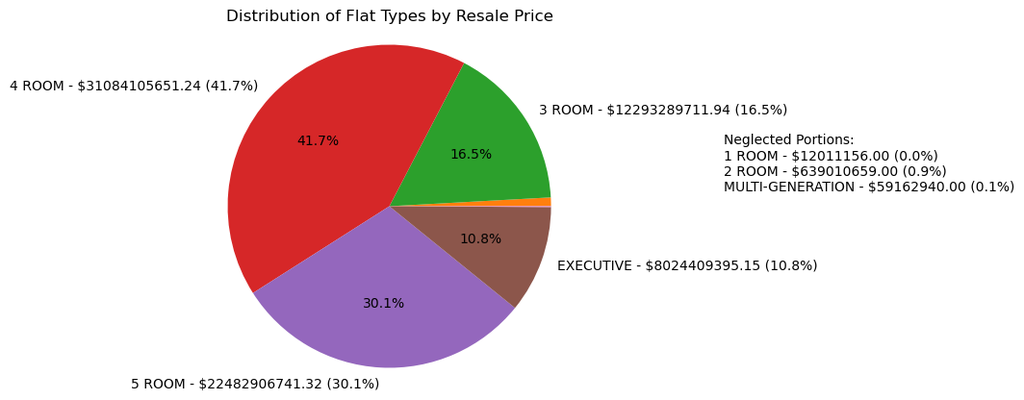

```python
import numpy as np
import matplotlib.pyplot as plt

# Load the dataset
data = np.genfromtxt('./resale-flat-prices-based-on-registration-date-from-jan-2017-onwards.csv',
                     delimiter=',',
                     dtype='str',
                     skip_header=True)

# Extract flat type and resale price columns
flat_types = data[:, 2]
resale_prices = data[:, -1].astype(float)

# Calculate the total resale price for each flat type
unique_flat_types, indices = np.unique(flat_types, return_inverse=True)
total_resale_prices = np.bincount(indices, weights=resale_prices)

# Calculate the total count
total_count = np.sum(total_resale_prices)

# Calculate the percentages
percentages = (total_resale_prices / total_count) * 100

# Create a list of labels by combining flat type, count, and percentage
labels = []
neglected_text = "Neglected Portions:\n"
for flat_type, percentage, resale_price in zip(unique_flat_types, percentages, total_resale_prices):
    if percentage < 1.0:
        neglected_text += f"{flat_type} - ${resale_price:.2f} ({percentage:.1f}%)\n"
        labels.append("")
    else:
        labels.append(f"{flat_type} - ${resale_price:.2f} ({percentage:.1f}%)")

# Create the pie chart
fig, ax = plt.subplots()
wedges, texts, autotexts = ax.pie(total_resale_prices, labels=labels, autopct='%1.1f%%')

# Set the title and aspect ratio
ax.set_title('Distribution of Flat Types by Resale Price')
ax.axis('equal')

# Add text indicating neglected portions
plt.text(1.2, 0.5, neglected_text, transform=ax.transAxes, fontsize=10)

# Hide labels and autotexts for neglected portions
for text, autotext in zip(texts, autotexts):
    if text.get_text() == "":
        text.set_visible(False)
        autotext.set_visible(False)

# Show the plot
plt.show()
```

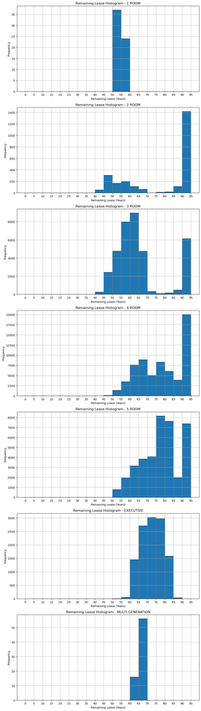

```python
import numpy as np
import matplotlib.pyplot as plt

data = np.genfromtxt('./resale-flat-prices-based-on-registration-date-from-jan-2017-onwards.csv',
                     delimiter=',',
                     dtype='str',
                     skip_header=True)

flat_types = data[:, 2]
remain_lease = data[:, -2]  # Use the correct column index for remaining lease

unique_flat_types = np.unique(flat_types)

# Calculate the number of rows and columns for the subplot grid
n_rows = len(unique_flat_types)
n_cols = 1

# Calculate the size of the figure based on the number of subplots
fig_width = 10
fig_height = 5 * n_rows

# Create the figure and subplots
fig, axs = plt.subplots(n_rows, n_cols, figsize=(fig_width, fig_height))

# Iterate over each unique flat type and plot the histogram for remaining lease
for i, flat_type in enumerate(unique_flat_types):
    # Get the remaining lease values for the current flat type
    flat_type_remain_lease = remain_lease[flat_types == flat_type]

    # Extract the years from remaining lease values
    years = []
    for lease in flat_type_remain_lease:
        years.append(int(lease.split()[0]))

    # Plot the histogram for the current flat type
    bins = np.arange(0, 100, 5)  # Define the bin edges
    axs[i].hist(years, bins=bins, edgecolor='black')
    axs[i].set_xticks(np.arange(0, 100, 5))
    axs[i].set_title(f"Remaining Lease Histogram - {flat_type}")
    axs[i].set_xlabel("Remaining Lease (Years)")
    axs[i].set_ylabel("Frequency")
    axs[i].grid(True)

# Adjust the spacing between subplots
plt.tight_layout()

# Show the figure with the subplots
plt.show()
```

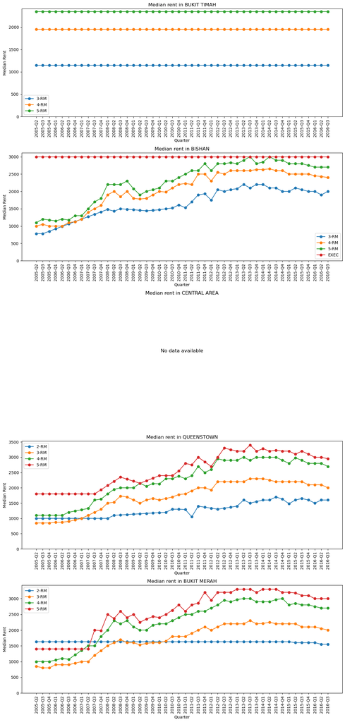

```python
import numpy as np
import matplotlib.pyplot as plt

# Load the dataset
data = np.genfromtxt('./median-rent-by-town-and-flat-type.csv', delimiter=',', dtype='str', skip_header=True)

# Extract the relevant columns from the dataset
quarter = data[:, 0]
town = data[:, 1]
flat_type = data[:, 2]
median_rent_str = data[:, 3]

# Convert 'na' values to numpy.nan
median_rent_str[(median_rent_str == 'na') | (median_rent_str == '-') | (median_rent_str == 'NA')] = np.nan

# Convert median_resale_str to float, ignoring the missing values
median_rent = median_rent_str.astype(float)

# Get the unique towns and flat types
unique_towns = np.unique(town)
unique_flat_types = np.unique(flat_type)
# Create a figure and axes for the plot
fig, axs = plt.subplots(len(selected_towns_high), 1, figsize=(12, 5 * len(selected_towns_high)))

# Iterate over each unique town
for i, current_town in enumerate(selected_towns_high):
    # Create a subplot for the current town
    ax = axs[i]

    # Create a list to store the dummy plots for the legend
    legend_plots = []

    # Iterate over each unique flat type
    for j, current_flat_type in enumerate(unique_flat_types):
        # Create a mask for the current town and flat type
        mask = (town == current_town) & (flat_type == current_flat_type)

        # Extract the relevant data for the current town and flat type
        town_data = quarter[mask]
        rent_data = median_rent[mask]

        mask = np.isnan(rent_data)

        if np.any(~mask):
            # Interpolate the missing values
            interpolated_rent_data = np.interp(np.arange(len(rent_data)), np.where(~mask)[0], rent_data[~mask])

            # Plot the interpolated data
            line, = ax.plot(town_data, interpolated_rent_data, marker='o')

            # Add the plot to the legend list with a hidden line
            legend_plots.append((line, current_flat_type))


    # Set the title and labels for each subplot
    ax.set_title(f"Median rent in {current_town}")
    ax.set_xlabel('Quarter')
    ax.set_ylabel('Median Rent')

    # Set the y-axis limits to start from 0
    ax.set_ylim(0, None)

    # Rotate the x-axis labels for better visibility
    ax.tick_params(axis='x', rotation=90)

    # Create the legend from the dummy plots
    if len(legend_plots) > 0:
        lines, labels = zip(*legend_plots)
        ax.legend(lines, labels)
    else :
         # Display a message if no data is available for the town
        ax.text(0.5, 0.5, 'No data available', horizontalalignment='center', verticalalignment='center', transform=ax.transAxes, fontsize=12)
        ax.axis('off')

# Adjust the spacing between subplots
plt.tight_layout()

# Show the plot
plt.show()
```

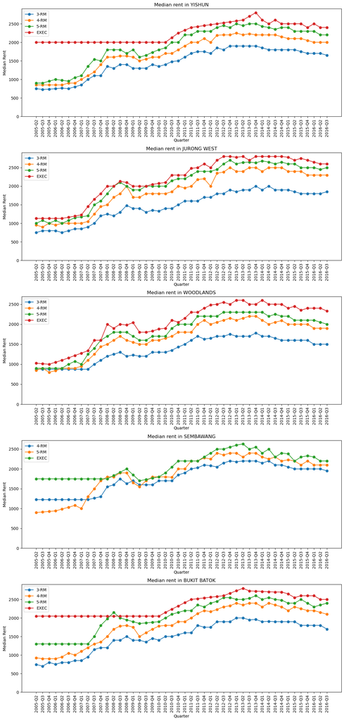

```python
import numpy as np
import matplotlib.pyplot as plt

# Load the dataset
data = np.genfromtxt('./median-rent-by-town-and-flat-type.csv', delimiter=',', dtype='str', skip_header=True)

# Extract the relevant columns from the dataset
quarter = data[:, 0]
town = data[:, 1]
flat_type = data[:, 2]
median_rent_str = data[:, 3]

# Convert 'na' values to numpy.nan
median_rent_str[(median_rent_str == 'na') | (median_rent_str == '-') | (median_rent_str == 'NA')] = np.nan

# Convert median_resale_str to float, ignoring the missing values
median_rent = median_rent_str.astype(float)

# Get the unique towns and flat types
unique_towns = np.unique(town)
unique_flat_types = np.unique(flat_type)
# Create a figure and axes for the plot
fig, axs = plt.subplots(len(selected_towns_low), 1, figsize=(12, 5 * len(selected_towns_low)))

# Iterate over each unique town
for i, current_town in enumerate(selected_towns_low):
    # Create a subplot for the current town
    ax = axs[i]

    # Create a list to store the dummy plots for the legend
    legend_plots = []

    # Iterate over each unique flat type
    for j, current_flat_type in enumerate(unique_flat_types):
        # Create a mask for the current town and flat type
        mask = (town == current_town) & (flat_type == current_flat_type)

        # Extract the relevant data for the current town and flat type
        town_data = quarter[mask]
        rent_data = median_rent[mask]

        mask = np.isnan(rent_data)

        if np.any(~mask):
            # Interpolate the missing values
            interpolated_rent_data = np.interp(np.arange(len(rent_data)), np.where(~mask)[0], rent_data[~mask])

            # Plot the interpolated data
            line, = ax.plot(town_data, interpolated_rent_data, marker='o')

            # Add the plot to the legend list with a hidden line
            legend_plots.append((line, current_flat_type))


    # Set the title and labels for each subplot
    ax.set_title(f"Median rent in {current_town}")
    ax.set_xlabel('Quarter')
    ax.set_ylabel('Median Rent')

    # Set the y-axis limits to start from 0
    ax.set_ylim(0, None)

    # Rotate the x-axis labels for better visibility
    ax.tick_params(axis='x', rotation=90)

    # Create the legend from the dummy plots
    if len(legend_plots) > 0:
        lines, labels = zip(*legend_plots)
        ax.legend(lines, labels)
    else :
         # Display a message if no data is available for the town
        ax.text(0.5, 0.5, 'No data available', horizontalalignment='center', verticalalignment='center', transform=ax.transAxes, fontsize=12)
        ax.axis('off')

# Adjust the spacing between subplots
plt.tight_layout()

# Show the plot
plt.show()
```

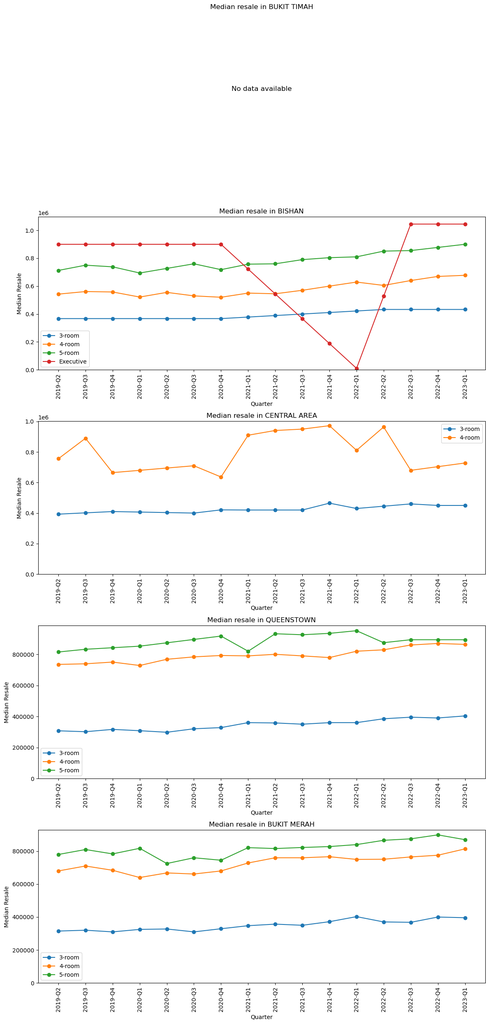

```python
import numpy as np
import matplotlib.pyplot as plt

# Load the dataset
data = np.genfromtxt('./median-resale-prices-for-registered-applications-by-town-and-flat-type.csv', delimiter=',', dtype='str', skip_header=True)

# Extract the relevant columns from the dataset
quarter = data[:, 0]
town = data[:, 1]
flat_type = data[:, 2]
median_resale_str = data[:, 3]

# Convert 'na' values to numpy.nan
median_resale_str[(median_resale_str == 'na') | (median_resale_str == '-') | (median_resale_str == 'NA')] = np.nan

# Convert median_resale_str to float, ignoring the missing values
median_resale = median_resale_str.astype(float)

# Get the unique towns and flat types
unique_towns = np.unique(town)
unique_flat_types = np.unique(flat_type)

# Create a figure and axes for the plot
fig, axs = plt.subplots(len(selected_towns_high), 1, figsize=(12, 5 * len(selected_towns_high)))

# Iterate over each unique town
for i, current_town in enumerate(selected_towns_high):
    # Create a subplot for the current town
    ax = axs[i]

    # Create a list to store the dummy plots for the legend
    legend_plots = []

    # Iterate over each unique flat type
    for j, current_flat_type in enumerate(unique_flat_types):
        # Create a mask for the current town and flat type
        mask = (town == current_town) & (flat_type == current_flat_type)

        # Extract the relevant data for the current town and flat type
        town_data = quarter[mask]
        resale_data = median_resale[mask]

        mask = np.isnan(resale_data)

        if np.any(~mask):
            # Interpolate the missing values
            interpolated_resale_data = np.interp(np.arange(len(resale_data)), np.where(~mask)[0], resale_data[~mask])

            # Plot the interpolated data
            line, = ax.plot(town_data, interpolated_resale_data, marker='o')

            # Add the plot to the legend list with a hidden line
            legend_plots.append((line, current_flat_type))


    # Set the title and labels for each subplot
    ax.set_title(f"Median resale in {current_town}")
    ax.set_xlabel('Quarter')
    ax.set_ylabel('Median Resale')

    # Set the y-axis limits to start from 0
    ax.set_ylim(0, None)

    # Rotate the x-axis labels for better visibility
    ax.tick_params(axis='x', rotation=90)

    # Create the legend from the dummy plots
    if len(legend_plots) > 0:
        lines, labels = zip(*legend_plots)
        ax.legend(lines, labels)
    else :
         # Display a message if no data is available for the town
        ax.text(0.5, 0.5, 'No data available', horizontalalignment='center', verticalalignment='center', transform=ax.transAxes, fontsize=12)
        ax.axis('off')

# Adjust the spacing between subplots
plt.tight_layout()

# Show the plot
plt.show()
```

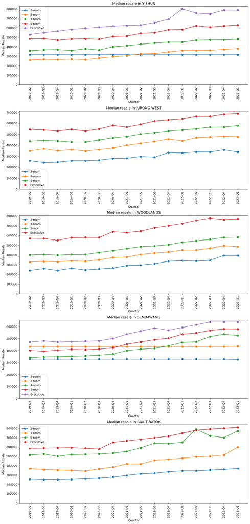

```python
import numpy as np
import matplotlib.pyplot as plt

# Load the dataset
data = np.genfromtxt('./median-resale-prices-for-registered-applications-by-town-and-flat-type.csv', delimiter=',', dtype='str', skip_header=True)

# Extract the relevant columns from the dataset
quarter = data[:, 0]
town = data[:, 1]
flat_type = data[:, 2]
median_resale_str = data[:, 3]

# Convert 'na' values to numpy.nan
median_resale_str[(median_resale_str == 'na') | (median_resale_str == '-') | (median_resale_str == 'NA')] = np.nan

# Convert median_resale_str to float, ignoring the missing values
median_resale = median_resale_str.astype(float)

# Get the unique towns and flat types
unique_towns = np.unique(town)
unique_flat_types = np.unique(flat_type)

# Create a figure and axes for the plot
fig, axs = plt.subplots(len(selected_towns_low), 1, figsize=(12, 5 * len(selected_towns_low)))

# Iterate over each unique town
for i, current_town in enumerate(selected_towns_low):
    # Create a subplot for the current town
    ax = axs[i]

    # Create a list to store the dummy plots for the legend
    legend_plots = []

    # Iterate over each unique flat type
    for j, current_flat_type in enumerate(unique_flat_types):
        # Create a mask for the current town and flat type
        mask = (town == current_town) & (flat_type == current_flat_type)

        # Extract the relevant data for the current town and flat type
        town_data = quarter[mask]
        resale_data = median_resale[mask]

        mask = np.isnan(resale_data)

        if np.any(~mask):
            # Interpolate the missing values
            interpolated_resale_data = np.interp(np.arange(len(resale_data)), np.where(~mask)[0], resale_data[~mask])

            # Plot the interpolated data
            line, = ax.plot(town_data, interpolated_resale_data, marker='o')

            # Add the plot to the legend list with a hidden line
            legend_plots.append((line, current_flat_type))


    # Set the title and labels for each subplot
    ax.set_title(f"Median resale in {current_town}")
    ax.set_xlabel('Quarter')
    ax.set_ylabel('Median Resale')

    # Set the y-axis limits to start from 0
    ax.set_ylim(0, None)

    # Rotate the x-axis labels for better visibility
    ax.tick_params(axis='x', rotation=90)

    # Create the legend from the dummy plots
    if len(legend_plots) > 0:
        lines, labels = zip(*legend_plots)
        ax.legend(lines, labels)
    else :
         # Display a message if no data is available for the town
        ax.text(0.5, 0.5, 'No data available', horizontalalignment='center', verticalalignment='center', transform=ax.transAxes, fontsize=12)
        ax.axis('off')

# Adjust the spacing between subplots
plt.tight_layout()

# Show the plot
plt.show()
```

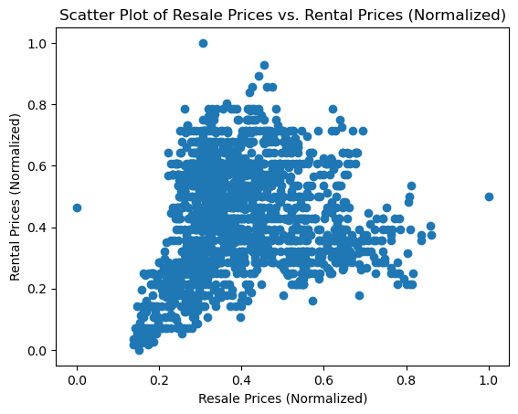

```python
import numpy as np
import matplotlib.pyplot as plt

data1 = np.genfromtxt('./median-rent-by-town-and-flat-type.csv', delimiter=',', dtype='str', skip_header=True)
data2 = np.genfromtxt('./median-resale-prices-for-registered-applications-by-town-and-flat-type.csv', delimiter=',', dtype='str', skip_header=True)

quarters1 = data1[:, 0]
years1 = np.array([int(q[:4]) for q in quarters1])

quarters2 = data2[:, 0]
years2 = np.array([int(q[:4]) for q in quarters2])

# Find the overlapping years between the datasets
common_years = np.intersect1d(years1, years2)

# Filter the data for the overlapping years
filtered_data1 = data1[np.isin(years1, common_years)]
filtered_data2 = data2[np.isin(years2, common_years)]

# Trim the datasets to have the same length
min_length = min(filtered_data1.shape[0], filtered_data2.shape[0])
filtered_data1 = filtered_data1[:min_length]
filtered_data2 = filtered_data2[:min_length]

# Replace 'na' values with np.nan in the merged dataset
merged_data = np.concatenate((filtered_data1[:, 3:], filtered_data2[:, 3:]), axis=1)
merged_data[(merged_data == 'na') | (merged_data == 'NA')] = np.nan
merged_data[merged_data == '-'] = np.nan

# Separate the merged data into resale prices and rental prices
resale_prices = merged_data[:, 1].astype(float)
rental_prices = merged_data[:, 0].astype(float)

# Filter out NaN values
resale_prices = resale_prices[~np.isnan(resale_prices)]
rental_prices = rental_prices[~np.isnan(rental_prices)]

# Normalize the data
resale_prices_normalized = (resale_prices - resale_prices.min()) / (resale_prices.max() - resale_prices.min())
rental_prices_normalized = (rental_prices - rental_prices.min()) / (rental_prices.max() - rental_prices.min())

# Create the scatter plot with normalized data
plt.scatter(resale_prices_normalized, rental_prices_normalized)
plt.xlabel('Resale Prices (Normalized)')
plt.ylabel('Rental Prices (Normalized)')
plt.title('Scatter Plot of Resale Prices vs. Rental Prices (Normalized)')

plt.show()
```

## Final conclusion

Based on a comprehensive analysis and insightful data visualization, several key conclusions can be drawn regarding the investment potential in different towns and flat types:

#### Preferred Flat Type:

Among the various flat types analyzed, the 4-room and 5-room categories emerge as the most favorable for investment. These flat types consistently display an upward trajectory in resale prices, indicating a higher demand and potential for capital appreciation. Investors looking for properties with a greater likelihood of long-term value appreciation may find these flat types particularly attractive.

#### Lease Durations:

A noteworthy observation from the analysis is the presence of a significant number of buildings in these categories with lease durations exceeding 65-70 years. This indicates that investors can expect greater stability and a potentially higher return on investment due to the longer lease durations. Properties with longer lease durations provide reassurance to investors and contribute to their overall confidence in the investment.